# Toronto BlueJays Moneyball Analyis

*Written by Savahnna L. Cunningham*

*Date: December 23, 2017*

# Introduction

MoneyBall Project The Oakland Athletics’ 2002 season was the team’s 35th in Oakland, California. It was also the 102nd season in franchise history. The Athletics finished first in the American League West with a record of 103-59.

Because of the team’s smaller revenues, Oakland is forced to find players undervalued by the market, and their system for finding value in undervalued players has proven itself thus far. This approach brought the A’s to the playoffs in 2002 and 2003.

The primary goal of this project is to use 2016 baseball statistics from Sean Lahaman’s Website (http://www.seanlahman.com/baseball-archive/statistics/) to find replacement players for the Toronto BlueJays. The Toronto Blue Jays are in the American League East division along with NY Yankees and Boston Red Soxs, needless to say I have my work cut out for me!

### Data

I’ll be using data from Sean Lahaman’s Website a very useful source for baseball statistics.

```r
head(Batting)
```

```
## # A tibble: 6 x 22
##   playe… year… stint team… lgID      G    AB     R     H  `2B`  `3B`    HR
##   <chr>  <int> <int> <chr> <chr> <int> <int> <int> <int> <int> <int> <int>
## 1 aberc…  1871     1 TRO   <NA>      1     4     0     0     0     0     0
## 2 addyb…  1871     1 RC1   <NA>     25   118    30    32     6     0     0
## 3 allis…  1871     1 CL1   <NA>     29   137    28    40     4     5     0
## 4 allis…  1871     1 WS3   <NA>     27   133    28    44    10     2     2
## 5 anson…  1871     1 RC1   <NA>     25   120    29    39    11     3     0
## 6 armst…  1871     1 FW1   <NA>     12    49     9    11     2     1     0
## # ... with 10 more variables: RBI <int>, SB <int>, CS <int>, BB <int>, SO
## #   <int>, IBB <int>, HBP <int>, SH <int>, SF <chr>, GIDP <chr>
```

[output not shown]

[output cut: 17 more lines]

[output not shown]

```r
#Call specific columns with the $ symbol
#Call the head() of the first 5 rows of the AB(At Bats) column
head(Batting$AB)
```

```
## [1]   4 118 137 133 120  49
```

```r
head(Batting$`2B`)
```

```
## [1]  0  6  4 10 11  2
```

## Important Baseball Statistics

*Batting Average* Batting average (BA) is defined by the number of hits(H) divided by at bats(AB). *On Base Percentage* On-base percentage is defined by the how frequently a batter reaches base.

OBP=(H+BB+HBP)/(AB+BB+HBP+SF))

where H = Hits BB = Bases on Balls (Walks) HBP = Hit By Pitch AB = At bat SF = Sacrifice fly

*Slugging Percentage*

Slugging percentage (SLG) is a measure of the batting productivity of a hitter. It is calculated as total bases divided by at bats, through the following formula, where AB is the number of at bats for a given player, and 1B, 2B, 3B, and HR are the number of singles, doubles, triples, and home runs, respectively:

SLG = ((1B) + (2 x 2B) + (3 x 3B) + (4 x HR)) / AB

Note: Unlike batting average, slugging percentage gives more weight to extra-base hits such as doubles and home runs, relative to singles. Walks are specifically excluded from this calculation, as a plate appearance that ends in a walk is not counted as an at bat.

```r
#Calculate BA Stat
Batting$BA <- Batting$H / Batting$AB

tail(Batting$BA,5)
```

```
## [1] 0.2500000 0.2177986 0.2715105 0.2073171       NaN
```

```r
#Calculate OBP Stat
Batting$OBP <- (Batting$H + Batting$BB + Batting$HBP)/
  (Batting$AB + Batting$BB + Batting$HBP + Batting$SF)

tail(Batting$OBP, 5)
```

```
## [1] 0.2500000 0.2719486 0.3859649 0.3177083       NaN
```

```r
#Calculate SLG Stat

#First calculate 1B
Batting$`1B` <- Batting$H - Batting$`2B` - Batting$`3B` - Batting$HR

#SLG
Batting$SLG <- ((Batting$`1B`) + (2 * Batting$`2B`) + (3 * Batting$`3B`) +
                  (4 * Batting$HR)) / Batting$AB

tail(Batting$SLG,5)
```

```
## [1] 0.2500000 0.3700234 0.4455067 0.4695122       NaN
```

```r
str(Batting)
```

```
## Classes 'tbl_df', 'tbl' and 'data.frame':    102816 obs. of  26 variables:
##  $ playerID: chr  "abercda01" "addybo01" "allisar01" "allisdo01" ...
##  $ yearID  : int  1871 1871 1871 1871 1871 1871 1871 1871 1871 1871 ...
##  $ stint   : int  1 1 1 1 1 1 1 1 1 1 ...
##  $ teamID  : chr  "TRO" "RC1" "CL1" "WS3" ...
##  $ lgID    : chr  NA NA NA NA ...
##  $ G       : int  1 25 29 27 25 12 1 31 1 18 ...
##  $ AB      : int  4 118 137 133 120 49 4 157 5 86 ...
##  $ R       : int  0 30 28 28 29 9 0 66 1 13 ...
##  $ H       : int  0 32 40 44 39 11 1 63 1 13 ...
##  $ 2B      : int  0 6 4 10 11 2 0 10 1 2 ...
##  $ 3B      : int  0 0 5 2 3 1 0 9 0 1 ...
##  $ HR      : int  0 0 0 2 0 0 0 0 0 0 ...
##  $ RBI     : int  0 13 19 27 16 5 2 34 1 11 ...
##  $ SB      : int  0 8 3 1 6 0 0 11 0 1 ...
##  $ CS      : int  0 1 1 1 2 1 0 6 0 0 ...
##  $ BB      : int  0 4 2 0 2 0 1 13 0 0 ...
##  $ SO      : int  0 0 5 2 1 1 0 1 0 0 ...
##  $ IBB     : int  NA NA NA NA NA NA NA NA NA NA ...
##  $ HBP     : int  NA NA NA NA NA NA NA NA NA NA ...
##  $ SH      : int  NA NA NA NA NA NA NA NA NA NA ...
##  $ SF      : num  NA NA NA NA NA NA NA NA NA NA ...
##  $ GIDP    : num  NA NA NA NA NA NA NA NA NA NA ...
##  $ BA      : num  0 0.271 0.292 0.331 0.325 ...
##  $ OBP     : num  NA NA NA NA NA NA NA NA NA NA ...
##  $ 1B      : int  0 26 31 30 25 8 1 44 0 10 ...
##  $ SLG     : num  0 0.322 0.394 0.481 0.467 ...
##  - attr(*, "spec")=List of 2
##   ..$ cols   :List of 22
##   .. ..$ playerID: list()
##   .. .. ..- attr(*, "class")= chr  "collector_character" "collector"
##   .. ..$ yearID  : list()
##   .. .. ..- attr(*, "class")= chr  "collector_integer" "collector"
##   .. ..$ stint   : list()
##   .. .. ..- attr(*, "class")= chr  "collector_integer" "collector"
##   .. ..$ teamID  : list()
##   .. .. ..- attr(*, "class")= chr  "collector_character" "collector"
##   .. ..$ lgID    : list()
##   .. .. ..- attr(*, "class")= chr  "collector_character" "collector"
##   .. ..$ G       : list()
```

[output cut: 21 more lines]

```
##   .. ..$ SO      : list()
##   .. .. ..- attr(*, "class")= chr  "collector_integer" "collector"
##   .. ..$ IBB     : list()
##   .. .. ..- attr(*, "class")= chr  "collector_integer" "collector"
##   .. ..$ HBP     : list()
##   .. .. ..- attr(*, "class")= chr  "collector_integer" "collector"
##   .. ..$ SH      : list()
##   .. .. ..- attr(*, "class")= chr  "collector_integer" "collector"
##   .. ..$ SF      : list()
##   .. .. ..- attr(*, "class")= chr  "collector_character" "collector"
##   .. ..$ GIDP    : list()
##   .. .. ..- attr(*, "class")= chr  "collector_character" "collector"
##   ..$ default: list()
##   .. ..- attr(*, "class")= chr  "collector_guess" "collector"
##   ..- attr(*, "class")= chr "col_spec"
```

```r
summary(Batting)
```

```
##    playerID             yearID         stint          teamID
##  Length:102816      Min.   :1871   Min.   :1.000   Length:102816
##  Class :character   1st Qu.:1934   1st Qu.:1.000   Class :character
##  Mode  :character   Median :1973   Median :1.000   Mode  :character
##                     Mean   :1964   Mean   :1.078
##                     3rd Qu.:1998   3rd Qu.:1.000
##                     Max.   :2016   Max.   :5.000
##
##      lgID                 G                AB              R
##  Length:102816      Min.   :  1.00   Min.   :  0.0   Min.   :  0.00
##  Class :character   1st Qu.: 13.00   1st Qu.:  4.0   1st Qu.:  0.00
##  Mode  :character   Median : 34.00   Median : 49.0   Median :  4.00
##                     Mean   : 51.34   Mean   :141.9   Mean   : 18.82
##                     3rd Qu.: 80.00   3rd Qu.:231.0   3rd Qu.: 27.00
##                     Max.   :165.00   Max.   :716.0   Max.   :192.00
##
##        H                2B               3B               HR
##  Min.   :  0.00   Min.   : 0.000   Min.   : 0.000   Min.   : 0.000
##  1st Qu.:  0.00   1st Qu.: 0.000   1st Qu.: 0.000   1st Qu.: 0.000
##  Median :  9.00   Median : 1.000   Median : 0.000   Median : 0.000
##  Mean   : 37.14   Mean   : 6.289   Mean   : 1.293   Mean   : 2.814
##  3rd Qu.: 58.00   3rd Qu.: 9.000   3rd Qu.: 1.000   3rd Qu.: 2.000
##  Max.   :262.00   Max.   :67.000   Max.   :36.000   Max.   :73.000
##
##       RBI            SB                CS               BB
##  Min.   :  0   Min.   :  0.000   Min.   : 0.000   Min.   :  0.00
##  1st Qu.:  0   1st Qu.:  0.000   1st Qu.: 0.000   1st Qu.:  0.00
##  Median :  3   Median :  0.000   Median : 0.000   Median :  3.00
##  Mean   : 17   Mean   :  2.977   Mean   : 1.226   Mean   : 13.07
##  3rd Qu.: 24   3rd Qu.:  2.000   3rd Qu.: 1.000   3rd Qu.: 18.00
##  Max.   :191   Max.   :138.000   Max.   :42.000   Max.   :232.00
##  NA's   :424   NA's   :1300      NA's   :23456
##        SO              IBB              HBP               SH
##  Min.   :  0.00   Min.   :  0.00   Min.   : 0.000   Min.   : 0.0
##  1st Qu.:  1.00   1st Qu.:  0.00   1st Qu.: 0.000   1st Qu.: 0.0
##  Median :  9.00   Median :  0.00   Median : 0.000   Median : 0.0
##  Mean   : 20.53   Mean   :  1.11   Mean   : 1.056   Mean   : 2.3
##  3rd Qu.: 29.00   3rd Qu.:  1.00   3rd Qu.: 1.000   3rd Qu.: 3.0
##  Max.   :223.00   Max.   :120.00   Max.   :51.000   Max.   :67.0
##  NA's   :7838     NA's   :36565    NA's   :2810     NA's   :6338
##        SF             GIDP              BA             OBP
##  Min.   : 0.00   Min.   : 0.000   Min.   :0.000   Min.   :0.00
##  1st Qu.: 0.00   1st Qu.: 0.000   1st Qu.:0.147   1st Qu.:0.19
##  Median : 0.00   Median : 0.000   Median :0.231   Median :0.29
##  Mean   : 1.05   Mean   : 2.981   Mean   :0.209   Mean   :0.26
##  3rd Qu.: 1.00   3rd Qu.: 4.000   3rd Qu.:0.274   3rd Qu.:0.34
##  Max.   :19.00   Max.   :36.000   Max.   :1.000   Max.   :1.00
##  NA's   :36034   NA's   :26110    NA's   :15381   NA's   :50964
##        1B              SLG
##  Min.   :  0.00   Min.   :0.000
##  1st Qu.:  0.00   1st Qu.:0.176
##  Median :  7.00   Median :0.309
##  Mean   : 26.74   Mean   :0.290
##  3rd Qu.: 42.00   3rd Qu.:0.398
##  Max.   :225.00   Max.   :4.000
##                   NA's   :15381
```

Notice we have data from 1871 to 2016 in the dataset to properly join the salary df with the batting df, I’m going to subset the batting df from 1985-2016.

```r
Batting <- subset(Batting,yearID >= 1985)
summary(Batting)
```

```
##    playerID             yearID         stint          teamID
##  Length:40577       Min.   :1985   Min.   :1.000   Length:40577
##  Class :character   1st Qu.:1994   1st Qu.:1.000   Class :character
##  Mode  :character   Median :2002   Median :1.000   Mode  :character
##                     Mean   :2002   Mean   :1.082
##                     3rd Qu.:2009   3rd Qu.:1.000
##                     Max.   :2016   Max.   :4.000
##
##      lgID                 G                AB              R
##  Length:40577       Min.   :  1.00   Min.   :  0.0   Min.   :  0.00
##  Class :character   1st Qu.: 14.00   1st Qu.:  0.0   1st Qu.:  0.00
##  Mode  :character   Median : 34.00   Median : 22.0   Median :  2.00
##                     Mean   : 50.91   Mean   :123.7   Mean   : 16.52
##                     3rd Qu.: 75.00   3rd Qu.:189.0   3rd Qu.: 22.00
##                     Max.   :163.00   Max.   :716.0   Max.   :152.00
##
##        H                2B               3B                HR
##  Min.   :  0.00   Min.   : 0.000   Min.   : 0.0000   Min.   : 0.000
##  1st Qu.:  0.00   1st Qu.: 0.000   1st Qu.: 0.0000   1st Qu.: 0.000
##  Median :  4.00   Median : 0.000   Median : 0.0000   Median : 0.000
##  Mean   : 32.36   Mean   : 6.228   Mean   : 0.7007   Mean   : 3.576
##  3rd Qu.: 47.00   3rd Qu.: 9.000   3rd Qu.: 1.0000   3rd Qu.: 3.000
##  Max.   :262.00   Max.   :59.000   Max.   :23.0000   Max.   :73.000
##
##       RBI               SB                CS               BB
##  Min.   :  0.00   Min.   :  0.000   Min.   : 0.000   Min.   :  0.0
##  1st Qu.:  0.00   1st Qu.:  0.000   1st Qu.: 0.000   1st Qu.:  0.0
##  Median :  1.00   Median :  0.000   Median : 0.000   Median :  1.0
##  Mean   : 15.65   Mean   :  2.359   Mean   : 1.016   Mean   : 11.9
##  3rd Qu.: 21.00   3rd Qu.:  1.000   3rd Qu.: 1.000   3rd Qu.: 16.0
##  Max.   :165.00   Max.   :110.000   Max.   :29.000   Max.   :232.0
##
##        SO              IBB                HBP               SH
##  Min.   :  0.00   Min.   :  0.0000   Min.   : 0.000   Min.   : 0.000
##  1st Qu.:  0.00   1st Qu.:  0.0000   1st Qu.: 0.000   1st Qu.: 0.000
##  Median :  6.00   Median :  0.0000   Median : 0.000   Median : 0.000
##  Mean   : 23.64   Mean   :  0.9733   Mean   : 1.102   Mean   : 1.217
##  3rd Qu.: 35.00   3rd Qu.:  1.0000   3rd Qu.: 1.000   3rd Qu.: 1.000
##  Max.   :223.00   Max.   :120.0000   Max.   :35.000   Max.   :39.000
##
##        SF              GIDP              BA             OBP
##  Min.   : 0.000   Min.   : 0.000   Min.   :0.000   Min.   :0.000
##  1st Qu.: 0.000   1st Qu.: 0.000   1st Qu.:0.133   1st Qu.:0.184
##  Median : 0.000   Median : 0.000   Median :0.232   Median :0.294
##  Mean   : 1.026   Mean   : 2.777   Mean   :0.204   Mean   :0.260
##  3rd Qu.: 1.000   3rd Qu.: 4.000   3rd Qu.:0.273   3rd Qu.:0.340
##  Max.   :17.000   Max.   :35.000   Max.   :1.000   Max.   :1.000
##                                    NA's   :10766   NA's   :10668
##        1B              SLG
##  Min.   :  0.00   Min.   :0.000
##  1st Qu.:  0.00   1st Qu.:0.164
##  Median :  3.00   Median :0.333
##  Mean   : 21.85   Mean   :0.302
##  3rd Qu.: 32.00   3rd Qu.:0.422
##  Max.   :225.00   Max.   :4.000
##                   NA's   :10766
```

```r
#Merge the Batting and Salary dataframes
combo <- merge(Batting,salary, by=c('playerID','yearID'))
summary(combo)
```

```
##    playerID             yearID         stint       teamID.x
##  Length:28287       Min.   :1985   Min.   :1.0   Length:28287
##  Class :character   1st Qu.:1994   1st Qu.:1.0   Class :character
##  Mode  :character   Median :2001   Median :1.0   Mode  :character
##                     Mean   :2001   Mean   :1.1
##                     3rd Qu.:2009   3rd Qu.:1.0
##                     Max.   :2016   Max.   :4.0
##
##     lgID.x                G                AB              R
##  Length:28287       Min.   :  1.00   Min.   :  0.0   Min.   :  0.00
##  Class :character   1st Qu.: 26.00   1st Qu.:  1.0   1st Qu.:  0.00
##  Mode  :character   Median : 50.00   Median : 57.0   Median :  4.00
##                     Mean   : 63.94   Mean   :161.9   Mean   : 21.79
##                     3rd Qu.:101.00   3rd Qu.:298.0   3rd Qu.: 37.00
##                     Max.   :163.00   Max.   :716.0   Max.   :152.00
##
##        H                2B               3B                HR
##  Min.   :  0.00   Min.   : 0.000   Min.   : 0.0000   Min.   : 0.000
##  1st Qu.:  0.00   1st Qu.: 0.000   1st Qu.: 0.0000   1st Qu.: 0.000
##  Median : 10.00   Median : 2.000   Median : 0.0000   Median : 0.000
##  Mean   : 42.64   Mean   : 8.223   Mean   : 0.9094   Mean   : 4.778
##  3rd Qu.: 76.00   3rd Qu.:14.000   3rd Qu.: 1.0000   3rd Qu.: 6.000
##  Max.   :262.00   Max.   :59.000   Max.   :23.0000   Max.   :73.000
##
##       RBI               SB                CS               BB
##  Min.   :  0.00   Min.   :  0.000   Min.   : 0.000   Min.   :  0.00
##  1st Qu.:  0.00   1st Qu.:  0.000   1st Qu.: 0.000   1st Qu.:  0.00
##  Median :  4.00   Median :  0.000   Median : 0.000   Median :  3.00
##  Mean   : 20.79   Mean   :  3.108   Mean   : 1.333   Mean   : 15.81
##  3rd Qu.: 34.00   3rd Qu.:  2.000   3rd Qu.: 2.000   3rd Qu.: 25.00
##  Max.   :165.00   Max.   :110.000   Max.   :29.000   Max.   :232.00
##
##        SO              IBB               HBP               SH
##  Min.   :  0.00   Min.   :  0.000   Min.   : 0.000   Min.   : 0.000
##  1st Qu.:  0.00   1st Qu.:  0.000   1st Qu.: 0.000   1st Qu.: 0.000
##  Median : 15.00   Median :  0.000   Median : 0.000   Median : 0.000
##  Mean   : 30.38   Mean   :  1.326   Mean   : 1.451   Mean   : 1.535
##  3rd Qu.: 50.00   3rd Qu.:  1.000   3rd Qu.: 2.000   3rd Qu.: 2.000
##  Max.   :223.00   Max.   :120.000   Max.   :35.000   Max.   :39.000
##
```

[output cut: 9 more lines]

```
##  Min.   :  0.00   Min.   :0.000   Length:28287       Length:28287
##  1st Qu.:  0.00   1st Qu.:0.200   Class :character   Class :character
##  Median :  7.00   Median :0.350   Mode  :character   Mode  :character
##  Mean   : 28.72   Mean   :0.316
##  3rd Qu.: 51.00   3rd Qu.:0.430
##  Max.   :225.00   Max.   :4.000
##                   NA's   :6476
##      salary
##  Min.   :       0
##  1st Qu.:  300000
##  Median :  600000
##  Mean   : 2111118
##  3rd Qu.: 2425000
##  Max.   :33000000
##
```

Key players Blue Jays lost in 2016 offseason: 1B Edwin Encarnacion, OF Michael Saunders, C Josh Thole

Since a player’s position is also very import to consider, I will merge the Fielding data set.

Merge the batting data with the salary and fielding data. Since there are players playing multiple years, the data will have repetitions of playerIDs for multiple years, to fix this I will join the data using both playerID and yearID.

```
## # A tibble: 6 x 18
##   playe… year… stint team… lgID  POS       G GS    InnO…    PO     A     E
##   <chr>  <int> <int> <chr> <chr> <chr> <int> <chr> <chr> <int> <int> <int>
## 1 zobri…  2016     1 CHN   NL    1B        1 0     1         1     0     0
## 2 zobri…  2016     1 CHN   NL    2B      119 113   2929    177   250     7
## 3 zobri…  2016     1 CHN   NL    OF       46 29    859      43     1     0
## 4 zobri…  2016     1 CHN   NL    SS        1 0     6         0     0     0
## 5 zunin…  2016     1 SEA   AL    C        52 48    1331    400    15     0
## 6 zycht…  2016     1 SEA   AL    P        12 0     41        0     0     1
## # ... with 6 more variables: DP <int>, PB <int>, WP <chr>, SB <chr>, CS
## #   <chr>, ZR <chr>
```

```r
field <- subset(field,yearID >= 1985)
summary(field)
```

```
##    playerID             yearID         stint         teamID
##  Length:52558       Min.   :1985   Min.   :1.00   Length:52558
##  Class :character   1st Qu.:1994   1st Qu.:1.00   Class :character
##  Mode  :character   Median :2002   Median :1.00   Mode  :character
##                     Mean   :2001   Mean   :1.08
##                     3rd Qu.:2009   3rd Qu.:1.00
##                     Max.   :2016   Max.   :4.00
##
##      lgID               POS                  G               GS
##  Length:52558       Length:52558       Min.   :  1.00   Length:52558
##  Class :character   Class :character   1st Qu.:  6.00   Class :character
##  Mode  :character   Mode  :character   Median : 20.00   Mode  :character
##                                        Mean   : 35.58
##                                        3rd Qu.: 50.00
##                                        Max.   :163.00
##
##    InnOuts                PO                A                E
##  Length:52558       Min.   :   0.00   Min.   :  0.00   Min.   : 0.000
##  Class :character   1st Qu.:   2.00   1st Qu.:  1.00   1st Qu.: 0.000
##  Mode  :character   Median :   8.00   Median :  5.00   Median : 1.000
##                     Mean   :  74.86   Mean   : 28.86   Mean   : 1.906
##                     3rd Qu.:  56.00   3rd Qu.: 19.00   3rd Qu.: 2.000
##                     Max.   :1597.00   Max.   :570.00   Max.   :42.000
##
##        DP                PB             WP                 SB
##  Min.   :  0.000   Min.   : 0.00   Length:52558       Length:52558
##  1st Qu.:  0.000   1st Qu.: 0.00   Class :character   Class :character
##  Median :  1.000   Median : 2.00   Mode  :character   Mode  :character
##  Mean   :  6.948   Mean   : 3.07
##  3rd Qu.:  3.000   3rd Qu.: 5.00
##  Max.   :176.000   Max.   :35.00
##                    NA's   :49026
##       CS                 ZR
##  Length:52558       Length:52558
##  Class :character   Class :character
##  Mode  :character   Mode  :character
##
##
##
##
```

```r
combo2 <- merge(combo,field, by=c('playerID','yearID'))
summary(combo2)
```

```
##    playerID             yearID        stint.x        teamID.x
##  Length:44704       Min.   :1985   Min.   :1.000   Length:44704
##  Class :character   1st Qu.:1994   1st Qu.:1.000   Class :character
##  Mode  :character   Median :2001   Median :1.000   Mode  :character
##                     Mean   :2001   Mean   :1.173
##                     3rd Qu.:2009   3rd Qu.:1.000
##                     Max.   :2016   Max.   :4.000
##
##     lgID.x               G.x               AB            R
##  Length:44704       Min.   :  1.00   Min.   :  0   Min.   :  0.00
##  Class :character   1st Qu.: 26.00   1st Qu.:  3   1st Qu.:  0.00
##  Mode  :character   Median : 53.00   Median : 92   Median : 10.00
##                     Mean   : 64.06   Mean   :167   Mean   : 22.05
##                     3rd Qu.: 99.00   3rd Qu.:284   3rd Qu.: 35.00
##                     Max.   :163.00   Max.   :716   Max.   :152.00
##
##        H                2B              3B                HR
##  Min.   :  0.00   Min.   : 0.00   Min.   : 0.0000   Min.   : 0.000
##  1st Qu.:  0.00   1st Qu.: 0.00   1st Qu.: 0.0000   1st Qu.: 0.000
##  Median : 21.00   Median : 4.00   Median : 0.0000   Median : 1.000
##  Mean   : 43.64   Mean   : 8.41   Mean   : 0.9299   Mean   : 4.619
##  3rd Qu.: 73.00   3rd Qu.:14.00   3rd Qu.: 1.0000   3rd Qu.: 6.000
##  Max.   :262.00   Max.   :59.00   Max.   :23.0000   Max.   :73.000
##
##       RBI              SB.x              CS.x              BB
##  Min.   :  0.00   Min.   :  0.000   Min.   : 0.000   Min.   :  0.00
##  1st Qu.:  0.00   1st Qu.:  0.000   1st Qu.: 0.000   1st Qu.:  0.00
##  Median :  8.00   Median :  0.000   Median : 0.000   Median :  7.00
##  Mean   : 20.86   Mean   :  3.019   Mean   : 1.369   Mean   : 15.98
##  3rd Qu.: 32.00   3rd Qu.:  3.000   3rd Qu.: 2.000   3rd Qu.: 25.00
##  Max.   :165.00   Max.   :110.000   Max.   :29.000   Max.   :232.00
##
##        SO              IBB               HBP               SH
##  Min.   :  0.00   Min.   :  0.000   Min.   : 0.000   Min.   : 0.000
##  1st Qu.:  1.00   1st Qu.:  0.000   1st Qu.: 0.000   1st Qu.: 0.000
##  Median : 19.00   Median :  0.000   Median : 0.000   Median : 0.000
##  Mean   : 31.09   Mean   :  1.252   Mean   : 1.476   Mean   : 1.539
##  3rd Qu.: 49.00   3rd Qu.:  1.000   3rd Qu.: 2.000   3rd Qu.: 2.000
##  Max.   :223.00   Max.   :120.000   Max.   :35.000   Max.   :39.000
##
```

[output cut: 41 more lines]

```
##  Min.   : 0.00   Length:44704       Length:44704       Length:44704
##  1st Qu.: 1.00   Class :character   Class :character   Class :character
##  Median : 3.00   Mode  :character   Mode  :character   Mode  :character
##  Mean   : 3.55
##  3rd Qu.: 5.00
##  Max.   :26.00
##  NA's   :41829
##       ZR
##  Length:44704
##  Class :character
##  Mode  :character
##
##
##
##
```

```r
lost_players <- subset(combo2, playerID %in% c('encared01','tholejo01','saundmi01'))
lost_players <- subset(lost_players,yearID == 2016)
lost_players <- lost_players[,c('playerID','POS','H','2B','3B','HR','OBP','SLG','BA','AB')]
print(lost_players)
```

```
##        playerID POS   H 2B 3B HR       OBP       SLG        BA  AB
## 11487 encared01  1B 158 34  0 42 0.3566334 0.5291181 0.2628952 601
## 36282 saundmi01  OF 124 32  3 24 0.3375224 0.4775510 0.2530612 490
## 40036 tholejo01   C  20  3  0  1 0.2537313 0.2203390 0.1694915 118
```

Find Replacement Players for the key three players Toronto lost in 2016 offseason! Constraints: 1. The total combined salary of the three players can not exceed 15 million dollars. 2. Their combined number of At Bats (AB) needs to be equal to or greater than the lost players. 3. Their mean OBP had to equal to or greater than the mean OBP of the lost players 4. Key playing positions must be considered- looking for a great 1B and Catcher!

```r
#Filter available players from year 2016
avail.players <- filter(combo2,yearID==2016)
```

[figure not shown]

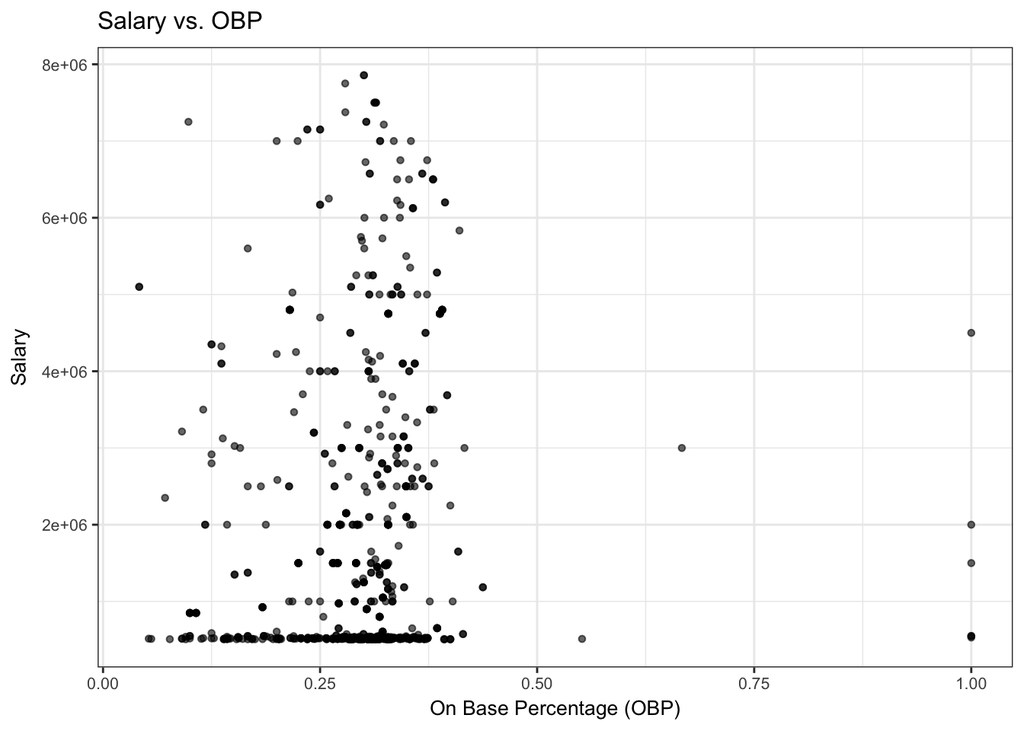

```r
#no point in paying above 8 million. There are also a lot of players with OBP==0. So I'll get rid of them too.
avail.players_update <- filter(avail.players,salary<8000000,OBP>0)
ggplot(avail.players_update,aes(x=OBP,y=salary)) +
  geom_point(alpha = 0.6, size = 1.2) +
  theme_bw()+
  ggtitle('Salary vs. OBP') +
  theme(text = element_text(size=10)) +
  labs(x='On Base Percentage (OBP)',y='Salary')
```

```r
#sort the players by OBP.
recruits <- head(arrange(avail.players,desc(OBP)),10)
recruits <- recruits[,c('playerID','POS','OBP','AB','salary')]
print(recruits)
```

```
##     playerID POS       OBP AB   salary
## 1  alberma01   P 1.0000000  1  2000000
## 2  capuach01   P 1.0000000  0  1500000
## 3  cingrto01   P 1.0000000  0   530000
## 4  gearrco01   P 1.0000000  1   550000
## 5  gearrco01  OF 1.0000000  1   550000
## 6  milonto01   P 1.0000000  2  4500000
## 7  perezol01   P 0.6666667  3  3000000
## 8  gallayo01   P 0.6000000  4  8728776
## 9  sucreje01   C 0.5517241 25   512000
## 10 nolasri01   P 0.5000000  1 12000000
```

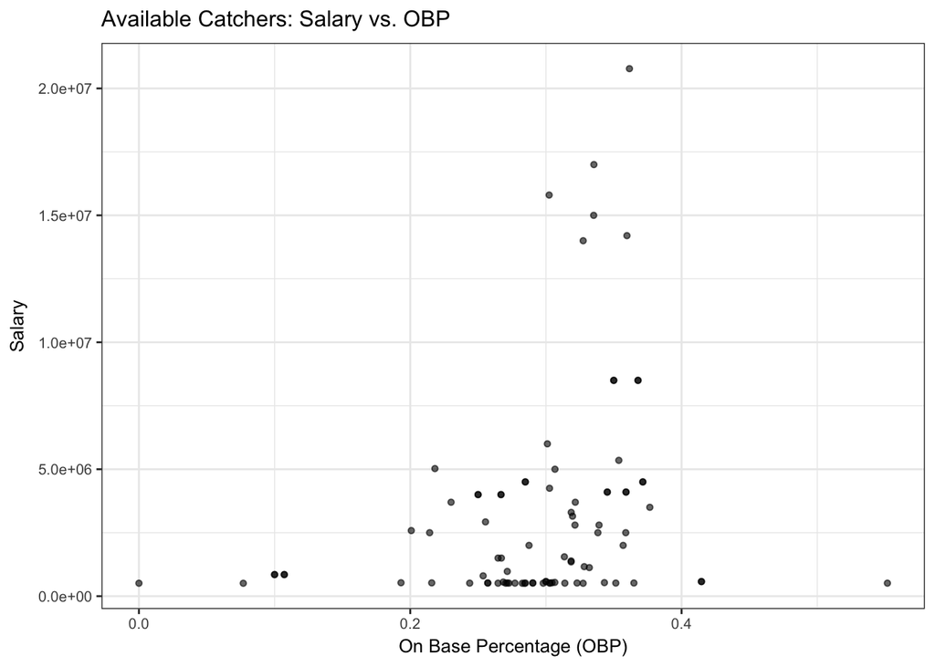

```r
#Hunt for a Catcher
avail.catchers<- filter(combo2,yearID==2016 & POS=="C")
ggplot(avail.catchers,aes(x=OBP,y=salary)) +
  geom_point(alpha = 0.6, size = 1.2) +
  theme_bw()+
  ggtitle('Available Catchers: Salary vs. OBP') +
  theme(text = element_text(size=10)) +
  labs(x='On Base Percentage (OBP)',y='Salary')
```

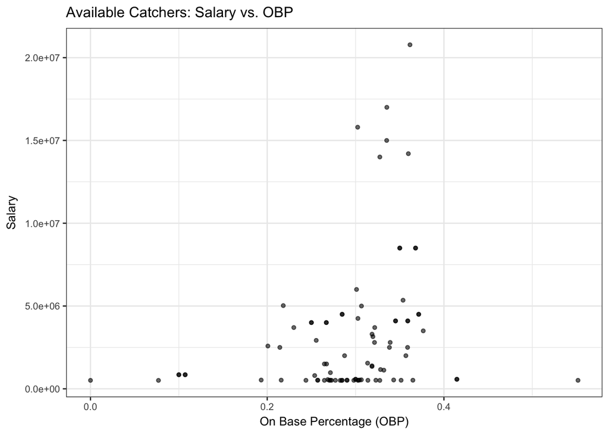

```r
avail.catchers<- filter(combo2,yearID==2016 & POS=="C")
ggplot(avail.catchers,aes(x=OBP,y=salary)) +
  geom_point(alpha = 0.6, size = 1.2) +
  theme_bw()+
  ggtitle('Available Catchers: Salary vs. OBP') +
  theme(text = element_text(size=10)) +
  labs(x='On Base Percentage (OBP)',y='Salary')
```

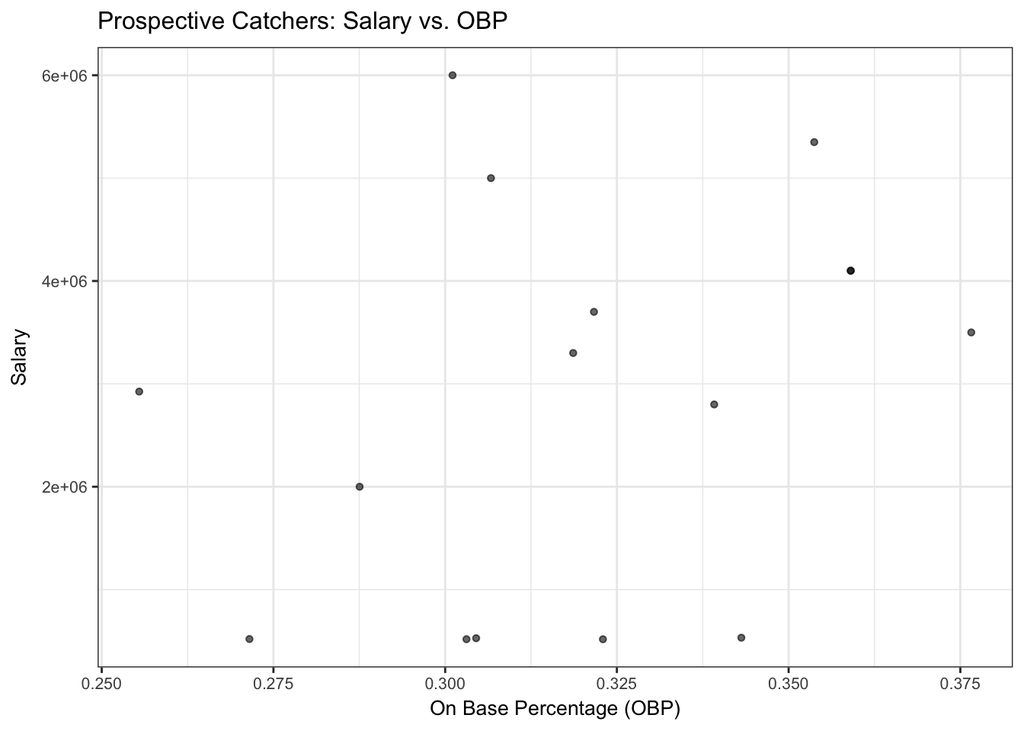

```r
avail.catchers <- filter(avail.catchers,salary<8000000,OBP>0)
avail.catchers <- filter(avail.catchers,AB >= 300)
ggplot(avail.catchers,aes(x=OBP,y=salary)) +
  geom_point(alpha = 0.6, size = 1.2) +
  theme_bw()+
  ggtitle('Prospective Catchers: Salary vs. OBP') +
  theme(text = element_text(size=10)) +
  labs(x='On Base Percentage (OBP)',y='Salary')
```

```r
catcher <- head(arrange(avail.catchers,desc(OBP)),10)
catcher<- catcher[,c('playerID','POS','OBP','AB','salary')]
View(catcher)
```

## Summary

```r
final_recruits <- subset(combo2,playerID %in% c('bryankr01','beltbr01','cervefr01'))
final_recruits<- final_recruits[,c('playerID','POS','OBP','AB','salary')]
final_recruits
```

```
##       playerID POS       OBP  AB  salary
## 2834  beltbr01  OF 0.3062201 187  414000
## 2835  beltbr01  1B 0.3062201 187  414000
## 2836  beltbr01  1B 0.3601695 411  481000
## 2837  beltbr01  OF 0.3601695 411  481000
## 2838  beltbr01  1B 0.3596491 509  531500
## 2839  beltbr01  1B 0.3063830 214 2900000
## 2840  beltbr01  OF 0.3063830 214 2900000
## 2841  beltbr01  OF 0.3561151 492 3600000
## 2842  beltbr01  1B 0.3561151 492 3600000
## 2843  beltbr01  1B 0.3938931 542 6200000
## 2844  beltbr01  OF 0.3938931 542 6200000
## 5329 bryankr01  OF 0.3848355 603  652000
## 5330 bryankr01  3B 0.3848355 603  652000
## 5331 bryankr01  SS 0.3848355 603  652000
## 5332 bryankr01  1B 0.3848355 603  652000
## 7281 cervefr01   C 0.3592233 266  410800
## 7282 cervefr01  3B 0.3592233 266  410800
## 7283 cervefr01  2B 0.3235294 124  455700
## 7284 cervefr01  3B 0.3235294 124  455700
## 7285 cervefr01   C 0.3235294 124  455700
## 7286 cervefr01   C 0.3770492  52  515350
## 7287 cervefr01  2B 0.3770492  52  515350
## 7288 cervefr01   C 0.3703704 146  700000
## 7289 cervefr01  1B 0.3703704 146  700000
## 7290 cervefr01   C 0.3695652 451  987500
## 7291 cervefr01  1B 0.3765903 326 3500000
## 7292 cervefr01   C 0.3765903 326 3500000
```